# ML Session Linear Regression

Ken

23 September 2018

# Some Info

I am teaching a course of Fundamentals of Data Visualisation and Statistical Analysis so if you are interested, have a look and ask your manager! http://www.coe.auckland.ac.nz/

# Linear Regression

Machine learning uses the similar concept but just more complicated and cooler so before we start recognising faces, let’s understand some concept!

The main uses of linear regression are: * Prediction * Find a relationship between response and explanatory variables

## Equation

$$y = intercept + \beta_1 x_1 + ... + \beta_n x_n + \epsilon$$
$intercept$ is the value when the explanatory Variable is 0. Thus it could be meaningless value when 0 is not appropriate. $\beta$ is the “impact towards y” by having the explanatory variables. And $\epsilon$ is the random variation in the data.

Basically, what it does is finding a line that produce the minimum error in the data set then finding the algebra equation for that line.

## Advertise Data revisited

Let’s go back to Daniel’s example to understand the linear regression.

```r
Sales.df <- read.csv(file.choose(), header = T) #Load Sales.csv data
head(Sales.df) #Fisrt few rows
```

```
##      TV Radio Newspaper Total.Adv Sales
## 1 230.1  37.8      69.2     337.1  22.1
## 2  44.5  39.3      45.1     128.9  10.4
## 3  17.2  45.9      69.3     132.4   9.3
## 4 151.5  41.3      58.5     251.3  18.5
## 5 180.8  10.8      58.4     250.0  12.9
## 6   8.7  48.9      75.0     132.6   7.2
```

```r
tail(Sales.df) #Last few rows
```

```
##        TV Radio Newspaper Total.Adv Sales
## 195 149.7  35.6       6.0     191.3  17.3
## 196  38.2   3.7      13.8      55.7   7.6
## 197  94.2   4.9       8.1     107.2   9.7
## 198 177.0   9.3       6.4     192.7  12.8
## 199 283.6  42.0      66.2     391.8  25.5
## 200 232.1   8.6       8.7     249.4  13.4
```

These codes above are equivalent to the code below in Python.

```
import pandas as pd
SalesPyth = pd.read_csv('~/advertising.csv', index_col=0)
SalesPyth.head() # display the first 5 rows
SalesPyth.tail() # display the first 5 rows
```

## Initial Plots

First of all, we check is there are any relationship between Sales and Advertisement. Remember, if there is no relationship, we cannot predict anything.

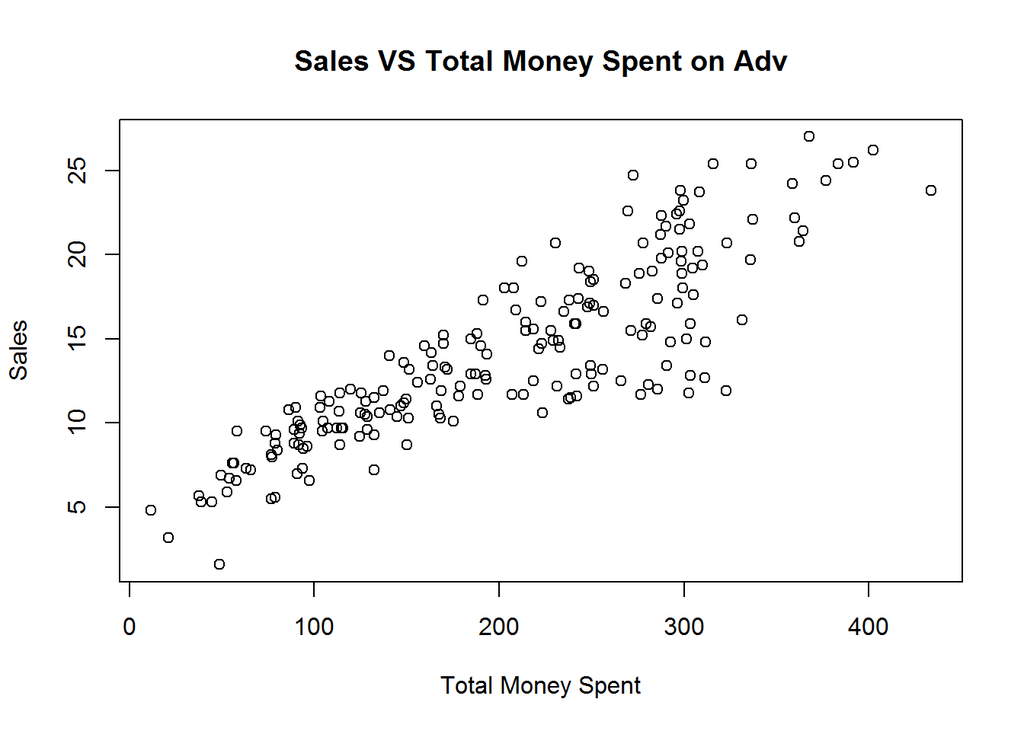

```r
plot(Sales~Total.Adv, data = Sales.df,
     main = "Sales VS Total Money Spent on Adv", #Title of plot
     ylab = "Sales", # y label
     xlab = "Total Money Spent" # x label
     )
```

Seems the more they spent on Advertisement, the more Sales they can expect.

## First Analysis

Let’s create a model like the one below to explain the relationship between Sale and Advertisement.

$$y = intercept + \beta_{Adv} x_{Adv} + \epsilon$$
$\beta_{Adv}$ shows the degree of “impact” of advertisement and $x_{Adv}$ represents the amount of money spent on Advertisement.

```r
Sales.lm <- lm(Sales~Total.Adv, data = Sales.df)
summary(Sales.lm)
```

```
##
## Call:
## lm(formula = Sales ~ Total.Adv, data = Sales.df)
##
## Residuals:
##     Min      1Q  Median      3Q     Max
## -8.0546 -1.3071  0.1173  1.5961  7.1895
##
## Coefficients:
##             Estimate Std. Error t value Pr(>|t|)
## (Intercept) 4.243028   0.438525   9.676   <2e-16 ***
## Total.Adv   0.048688   0.001982  24.564   <2e-16 ***
## ---
## Signif. codes:  0 '***' 0.001 '**' 0.01 '*' 0.05 '.' 0.1 ' ' 1
##
## Residual standard error: 2.6 on 198 degrees of freedom
## Multiple R-squared:  0.7529, Adjusted R-squared:  0.7517
## F-statistic: 603.4 on 1 and 198 DF,  p-value: < 2.2e-16
```

$R^2$ value for this model is 0.7529246 which means we can explain about 75% of sales variation by Total Money Spent on Adv.

Let’s see how it looks like in the original plot!

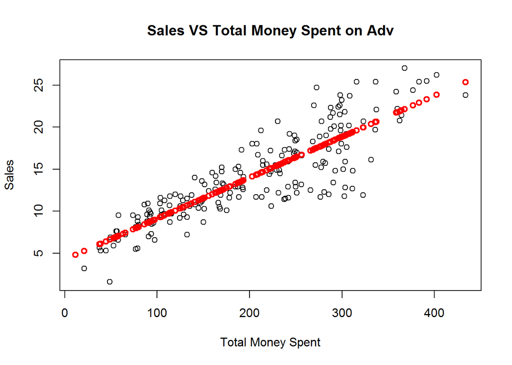

```r
plot(Sales~Total.Adv , data = Sales.df,
     main = "Sales VS Total Money Spent on Adv", #Title of plot
     ylab = "Sales", # y label
     xlab = "Total Money Spent" # x label
)
points(predict(Sales.lm, newdata = data.frame(Total.Adv = sort(Sales.df$Total.Adv)))~sort(Sales.df$Total.Adv),
              lwd = 2, col = "red")
```

What do you think?

## Add more explanatory variables (attributes)

We know that the impact of advertise differs depending on the platform… like below!

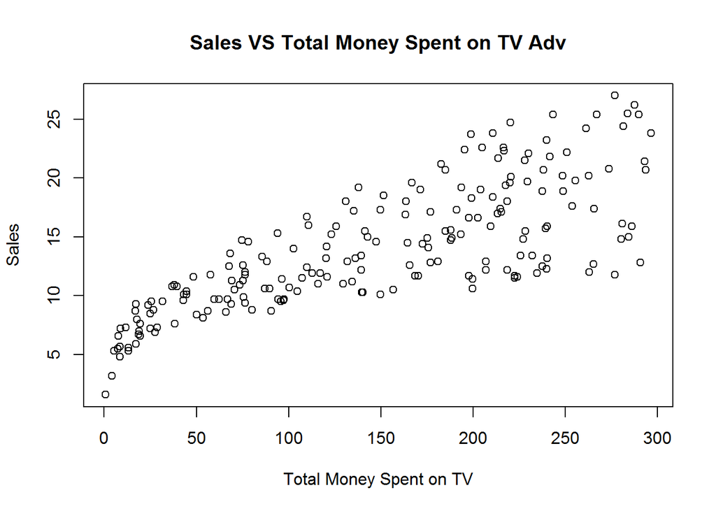

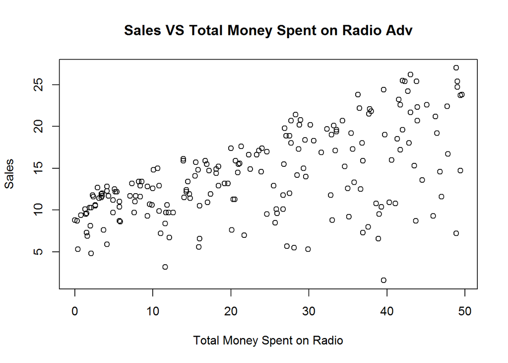

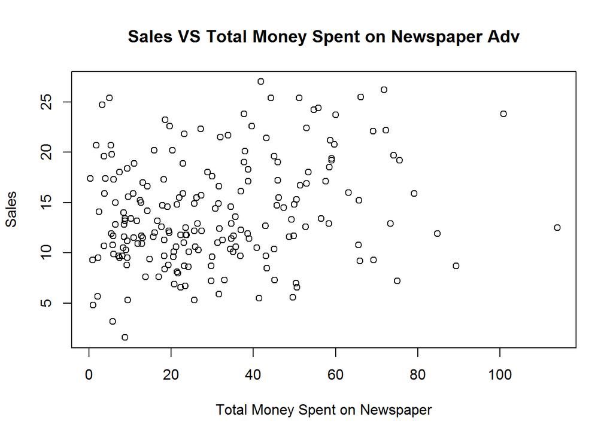

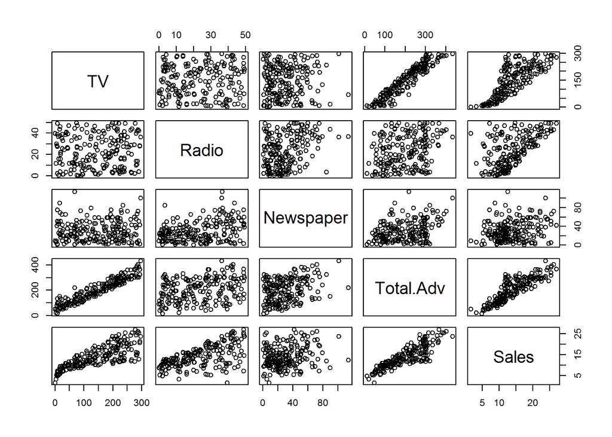

```r
pairs(Sales.df)
```

Or we can do something like this too.

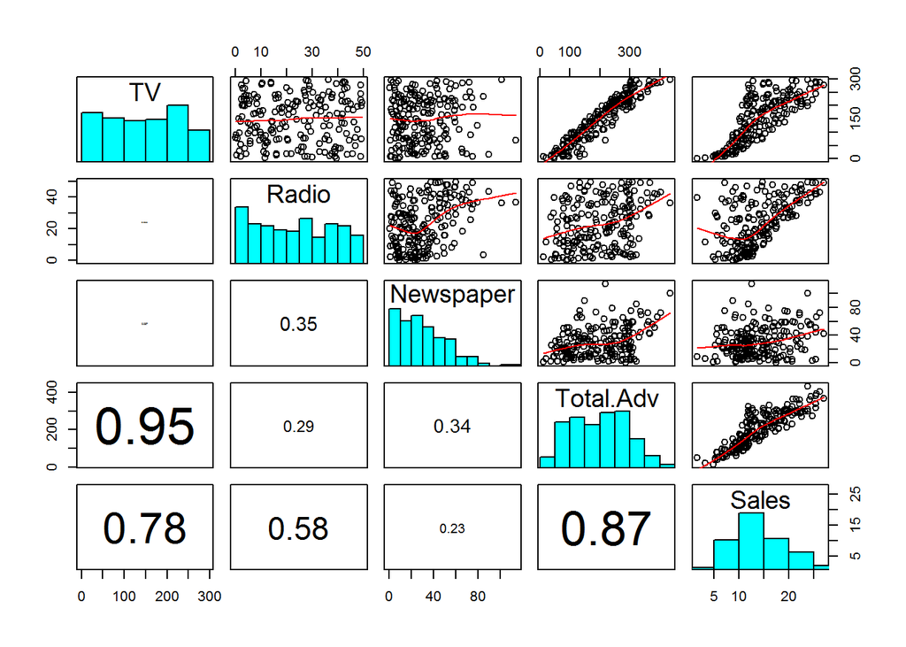

```r
library(s20x)
pairs20x(Sales.df)
```

## Fit a new model?

Maybe we can feed some detailed information to the model?

```r
Sales.lm2 <- lm(Sales~ TV + Radio + Newspaper, data = Sales.df) # Modeling part
summary(Sales.lm2) # Show result of the model
```

```
##
## Call:
## lm(formula = Sales ~ TV + Radio + Newspaper, data = Sales.df)
##
## Residuals:
##     Min      1Q  Median      3Q     Max
## -8.8277 -0.8908  0.2418  1.1893  2.8292
##
## Coefficients:
##              Estimate Std. Error t value Pr(>|t|)
## (Intercept)  2.938889   0.311908   9.422   <2e-16 ***
## TV           0.045765   0.001395  32.809   <2e-16 ***
## Radio        0.188530   0.008611  21.893   <2e-16 ***
## Newspaper   -0.001037   0.005871  -0.177     0.86
## ---
## Signif. codes:  0 '***' 0.001 '**' 0.01 '*' 0.05 '.' 0.1 ' ' 1
##
## Residual standard error: 1.686 on 196 degrees of freedom
## Multiple R-squared:  0.8972, Adjusted R-squared:  0.8956
## F-statistic: 570.3 on 3 and 196 DF,  p-value: < 2.2e-16
```

Since we the result shows Newpaper do not add any significant impact towards the sales, we can drop it from our morel!

```r
Sales.lm2 <- lm(Sales~ TV + Radio, data = Sales.df) # Modeling part
summary(Sales.lm2) # Show result of the model
```

```
##
## Call:
## lm(formula = Sales ~ TV + Radio, data = Sales.df)
##
## Residuals:
##     Min      1Q  Median      3Q     Max
## -8.7977 -0.8752  0.2422  1.1708  2.8328
##
## Coefficients:
##             Estimate Std. Error t value Pr(>|t|)
## (Intercept)  2.92110    0.29449   9.919   <2e-16 ***
## TV           0.04575    0.00139  32.909   <2e-16 ***
## Radio        0.18799    0.00804  23.382   <2e-16 ***
## ---
## Signif. codes:  0 '***' 0.001 '**' 0.01 '*' 0.05 '.' 0.1 ' ' 1
##
## Residual standard error: 1.681 on 197 degrees of freedom
## Multiple R-squared:  0.8972, Adjusted R-squared:  0.8962
## F-statistic: 859.6 on 2 and 197 DF,  p-value: < 2.2e-16
```

$R^2$ value for this model is 0.8971943 which means we can explain about 90% of sales variation by TV and Radio Adv!

Slightly better?

Let’s see how it looks like in the plot!

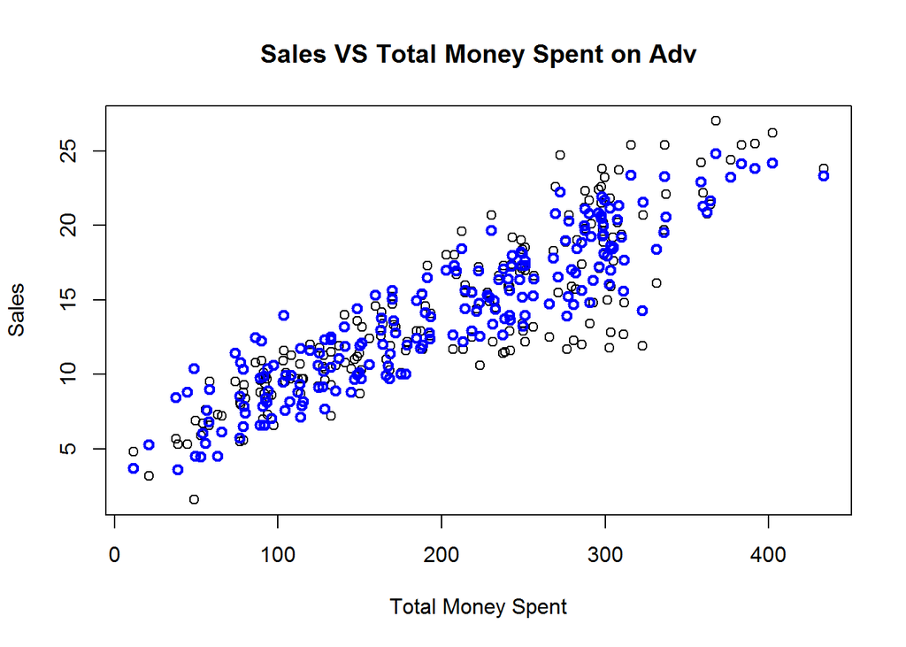

Not bad, right?

## Adv and Disadv

The advantages of LR:

- Easy to use
- Can explain relationship well
- Can predict well time to time

The disadvantages of LR:

- Not easy to read the output
- Constrained by a p-value (well, not even one but many of them!)
- Model can be very complicated (quadratic term, transformation, and etc…)